# R Notebook

### Intro

The highly controversial 1968 *Terry v. Ohio* Supreme Court case ruled that police officers, even when lacking probable cause for an arrest, can search someone’s belongings (aka “frisk”) in order find weapons if the officer suspects that the person being searched is armed and dangerous at the time of the search. This ruling set the stage for the policy that would later be known as stop and frisk to be put into law in New York City. Despite criticism leveled at the program, it was not put in place without reason. Along with many other police reforms of the time, this new course of action was part of a “broken windows” theory of crime prevention. This theory posits that the best way to prevent crime is to crack down on so-called low-level offences, because those crimes create an environment in which more serious breaches of the law become more acceptable or commonplace. In the modern age, proponents of stop and frisk (or other similar policies) argue that by showing low-level offenders the consequences of their actions before they partake in serious crime, more dangerous crimes will be discouraged. While these may seem to be reasonable theories for preventing crime, the actual execution of stop and frisk was anything but ideal. Perhaps foremost among the problems with the implementation of stop and frisk was the sheer number of stops that occurred. At their peak in 2011, about 685,000 stops occurred in a single year. Furthermore, many of those stops (over 80%) did not result in an arrest (NYCLU). To add to the mess, accusations that the police were racially profiling young African American and Hispanic men were rampant. These accusations were not just hot air, either. The 2013 case Floyd v. City of New York ruled that stop and frisk had been used in a racial discriminatory and thus, unconstitutional manner. Since that time, the number of reported stop and frisk cases has dropped precipitously. However, questions about the current state of policing in NYC still remain. Is racial profiling still occuring? How many stops happen in a year? How succesful are these stops at finding and arresting criminals? These questions, and many others, are the focus of this project.

### The Data

Our data is taken from the New York Civil Liberties Union (NYCLU); the data is collected for the purpose of understanding how and why stops occur. In particular, the NYCLU is interested in the racial disparities in the use of policies like stop-and-frisk. However, there are several important flaws in how this data is collected. First, it is self-reported in three different ways. Each case is a record created by an officer (or group of officers) which may be biased in what information they include or how that information is presented. While idiosyncratic biases might be washed out by the size of the data set, systemic bias may produce patterns in the data which are not reflective of the reality of police interactions with ordinary people in NYC. Some of this data is also self-reported in the sense that it is reported by those who are searched, for example, no “age” category is in the data set; instead, there is a “reported age” category. Furthermore, this data as a whole is turned over by a department, which may have incentives of its own to conceal and manipulate facts this data can convey. The exact extent (or existance) of any systemic manipulations in this data set are beyond the scope of this project. However, especially when it comes to choices made by officers (such as whether to search or arrest someone), there may be systematic biases that distort these data as compared to the real world.

Thus, for example, it is difficult to say that a stop is ‘succesful’ if it results in an arrest, because factors that result in an unneeded stop may also result in an unnecessary arrest. Furthermore, such errors may well be systemic; for example, it may be that some communities are targeted for arrest at disproportionately high rates. Furthermore, as part of a “broken windows” strategy, many encounters with the police may be the point of continous stops in a certain region or among a certain community, simply because it sends the message that law enforcement are constantly on the lookout for any crimes (or criminals). In this way, limitations in both the data set (convictions are absent here, for example) and in knowledge of future behaviour of both police and those stopped by police, render certain types of questions quite difficult to answer. However, there is still some merit to using what data is available to dig into the behaviour of NYC residents and the police officers that serve the city.

### Results

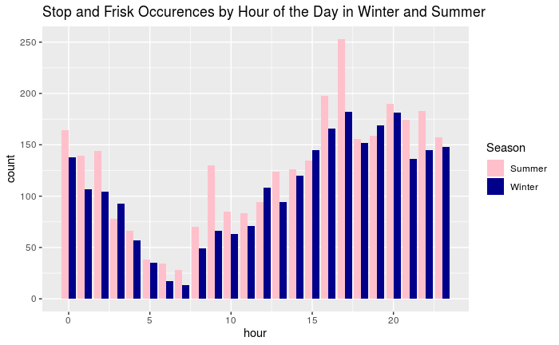

```r
stopFrisk %>%
  mutate(Season = ifelse(month < 3, "Winter",
                         ifelse(month == 12, "Winter",
                                ifelse(month > 5, "Other",
                                       ifelse(month < 9, "Summer", "Other"))))) %>%
  filter(Season != "Other") %>%
  drop_na(Season, hour) %>%
  mutate(Season = as.factor(Season)) %>%
  ggplot(aes(x = hour, fill = Season)) +
    geom_bar(position = "dodge") +
    labs(title = "Stop and Frisk Occurences by Hour of the Day in Winter and Summer") +
    scale_fill_manual(values = c("pink", "dark blue"))
```

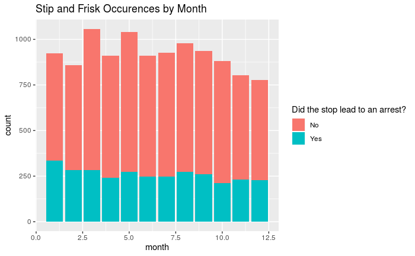

Therefore, these trends in police stop-and-frisk occurrences might be explained by the natural ebb and flow of people being outside. On the other hand, it may be that police officers are more reluctant to stand outside searching for criminal activity in the winter months as compared to summer months, or that conditions such as icy roads or adverse weather conditions may impede the type of police activity that leads to stops. Further, it may be that similar numbers of people are on the streets in NYC in the early morning (it is the city that never sleeps, after all) but that the number of police officers outside at that time is diminished. Thus, if one wishes to avoid being stopped by police (for whatever reason), it may at first seem reasonable to sneak outside in the very early morning. However, it may be that among people outside at, say, 3:00 AM, a higher proportion of people are stopped by police as compared to people who are outside during the evening. Without data on when NYC residents tend to be outside in large numbers, it is difficult to draw any concrete conclusions about when people are most likely to be stopped.

Taking a brief look at days of the week, there do appear to be fewer stops made on certain days of the week, namely Sundays and Mondays. However, there does not appear to be a pattern in stops by week day beyond that fact. Again, it is difficult to determine what is responsible for this trend. One possible explanation is that fewer people are out and about on Sundays and Mondays as compared to the rest of the week (which might apply to the police as well as the general population).

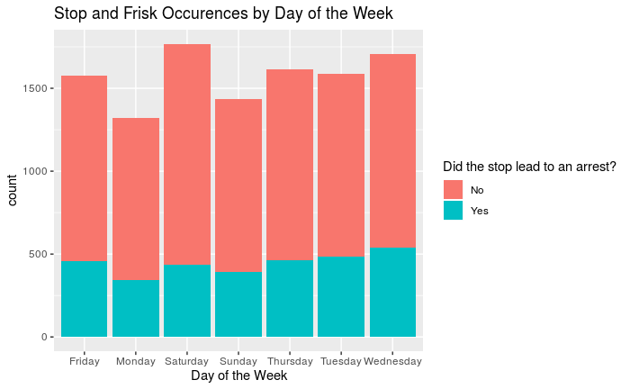

```r
ggplot(stopFrisk, aes(x = DAY2, fill = SUSPECT_ARRESTED_FLAG)) +
  geom_bar() +
  labs(title = "Stop and Frisk Occurences by Day of the Week",
       x = "Day of the Week",
       fill = "Did the stop lead to an arrest?")
```

### Works Cited

“Stop-and-Frisk Data.” New York Civil Liberties Union. New York Civil Liberties Union, March 11, 2020. https://www.nyclu.org/en/stop-and-frisk-data.

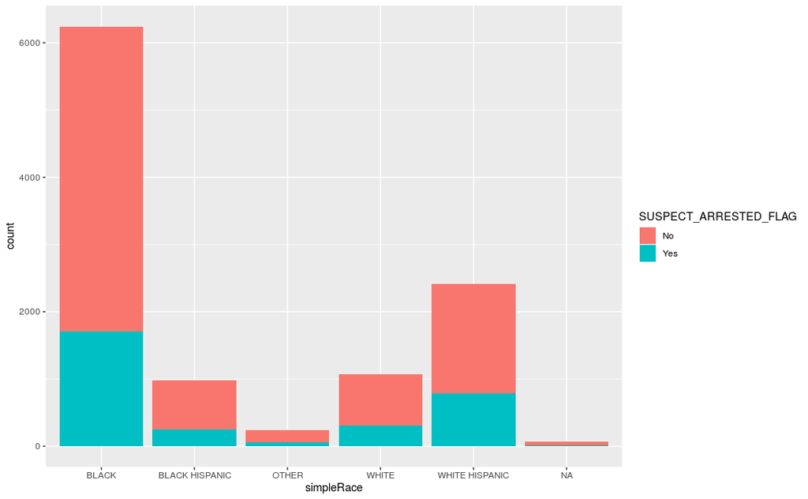

```r
stopFrisk %>%
  mutate(simpleRace = ifelse(str_length(SUSPECT_RACE_DESCRIPTION) > 14, "OTHER", SUSPECT_RACE_DESCRIPTION)) %>%
  ggplot(aes(x = simpleRace, fill = SUSPECT_ARRESTED_FLAG)) +
    geom_bar()
```

[figure not shown]

```r
stopFrisk %>%
  drop_na(SUSPECT_SEX) %>%
  group_by(SUSPECT_SEX) %>%
  summarize(ProportionArrested = sum(SUSPECT_ARRESTED_FLAG == "Y")/sum(n())) %>%
  ggplot(aes(x = SUSPECT_SEX, y = ProportionArrested)) +
    geom_bar(stat = "identity")
```

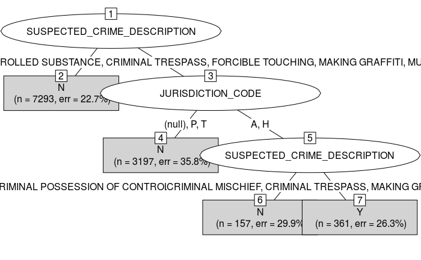

```r
data <- read_csv("2018_sqf_database.csv") %>%
  mutate(class = ifelse(SUSPECT_ARRESTED_FLAG %in% c(NA, "(null)", "N"), "N", "Y"))
set.seed(674991)
train_ind <- sample(nrow(data), floor(0.8*nrow(data)))
train <- slice(data, train_ind)
test <- slice(data, -train_ind)
DT <- rpart(
  class ~ JURISDICTION_CODE + OBSERVED_DURATION_MINUTES +
    SUSPECTED_CRIME_DESCRIPTION + OTHER_PERSON_STOPPED_FLAG +
    SUSPECT_REPORTED_AGE + SUSPECT_RACE_DESCRIPTION + STOP_LOCATION_PRECINCT,
  data = data
)
plot(as.party(DT), type = "simple")
```